# Predicting Bike rentals

Joel Casillas, Ravinder Singh, and Ryan LeBon

May 8, 2018

# Introduction

This dataset contains the hourly and daily count of rental bikes between years 2011 and 2012 in Capital bikeshare system with the corresponding weather and seasonal information. The data set is fairly new and small in the sense that it has only has 2 years of data. So any predictions created must be taken lighlty. The data set has 731 rows, and 16 columns total.

Capital Bikeshare is metro DC’s bikeshare service, with 4,300 bikes and 500 stations across 5 jurisdictions: Washington, DC.; Arlington, VA; Alexandria, VA; Montgomery, MD and Fairfax County, VA. Designed for quick trips with convenience in mind, it’s a fun and affordable way to get around.

Hypothesis: Our goal for this project is to predict the bicycle rentals.

# Data Cleaning & Pre-Processing

There were two types of data sets from the start. A ‘day’ dataset and an ‘hour’ dataset. The data was clean from the start, their were no Na’s or missing values in it. We removed a few columns from the dataset, we removed “instance”,“casual”,“registered”, and “dteday”. These columns were removed because they either negatively affected the models and or they were redundant columns made up of other columns data.

```r
dat=read.csv("https://raw.githubusercontent.com/Ryanbbq/datascience_final/master/day.csv")
hour=read.csv("https://raw.githubusercontent.com/Ryanbbq/datascience_final/master/hour.csv")
```

# Data Exploration

We will be exploring the data to see whether this data is consists of supervised or unspervised learning. We will also learn about the features and how they correlate and interact with each other.

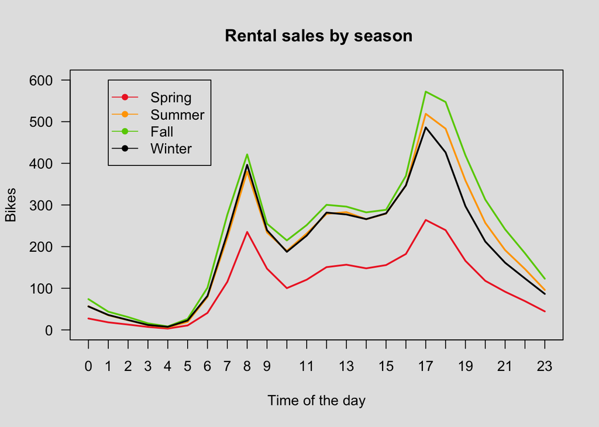

```r
season_1 = hour[hour$season ==1,]
season_2 = hour[hour$season ==2,]
season_3 = hour[hour$season ==3,]
season_4 = hour[hour$season ==4,]
x1 = aggregate(cnt~hr , data = season_1 , mean)
x2 = aggregate(cnt~hr , data = season_2 , mean)
x3 = aggregate(cnt~hr , data = season_3 , mean)
x4 = aggregate(cnt~hr , data = season_4 , mean)
par(bg = 'gray89')
plot(x1 , type = "l" , col = "firebrick2" , ylim =c(0 , 600) , xlim = c(0,23), lwd = 2 , main = " Rental sales by season", las=1 , xaxt = "n" , ylab = "Bikes" , xlab = "Time of the day")
axis(1, at = seq(0, 24, by = 1), las=1)
lines(x2 , type = "l" , col ="orange" , lwd =2)
lines(x3 , type = "l" , col ="chartreuse3" ,lwd =2)
lines(x4 , type = "l" , col ="black" ,lwd =2)
legend(1 ,600 ,c('Spring' , 'Summer' , 'Fall', 'Winter') , col = c("firebrick2","orange" , "chartreuse3" , "black"),lty= 1 ,pch = 16)
```

We learned that the data is consisted of Supervised Learning, and that it’s also regression.

We have four seasons in numerical values such as, spring as 1 , summer as 2 , fall as 3 and winter as 4. We plotted the total rental sales for each season in this plot. We can clearly see that fall and summer has the highest sales as we expected.

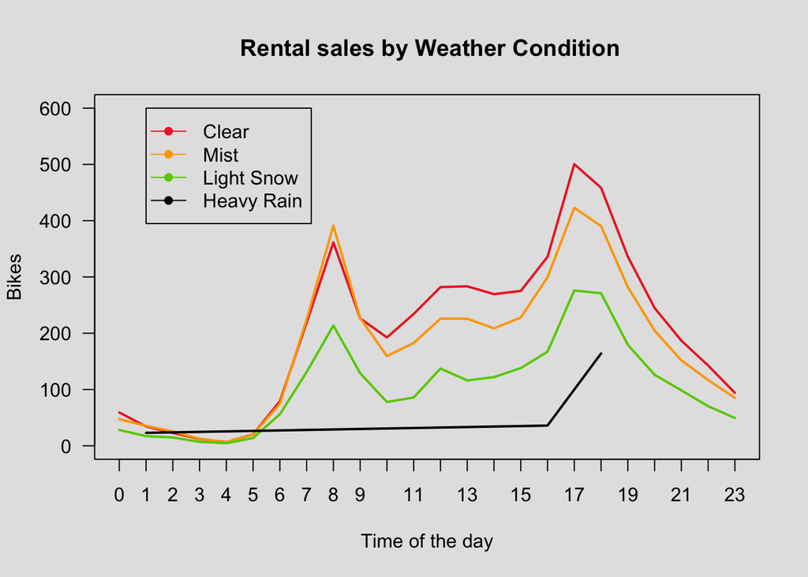

```r
weather_1 = hour[hour$weathersit ==1,]
weather_2 = hour[hour$weathersit ==2,]
weather_3 = hour[hour$weathersit ==3,]
weather_4 = hour[hour$weathersit ==4,]
y1 = aggregate(cnt~hr , data = weather_1 , mean)
y2 = aggregate(cnt~hr , data = weather_2 , mean)
y3 = aggregate(cnt~hr , data = weather_3 , mean)
y4 = aggregate(cnt~hr , data = weather_4 , mean)
par(bg = 'gray89')
plot(y1 , type = "l" , col = "firebrick2" , ylim =c(0 , 600) , xlim = c(0,23), lwd = 2 , main = " Rental sales by Weather Condition", las=1 , xaxt = "n" , ylab = "Bikes" , xlab = "Time of the day")
axis(1, at = seq(0, 24, by = 1), las=1)
lines(y2 , type = "l" , col ="orange" , lwd =2)
lines(y3 , type = "l" , col ="chartreuse3" ,lwd =2)
lines(y4 , type = "l" , col ="black" ,lwd =2)
legend(1 ,600 ,c('Clear' , 'Mist' , 'Light Snow', 'Heavy Rain') , col = c("firebrick2","orange" , "chartreuse3" , "black"),lty= 1 ,pch = 16)
```

We have each day’s condition as clear, mist, little snow or heavy rain. Also, we have each day’s condition as numeric values from 1 to 4. We were expecting to see most of the rental sales on clear days. As we expected, most of the rental sales were on a clear day. Also, there were no sales at all on heavy rain after 18 hours.

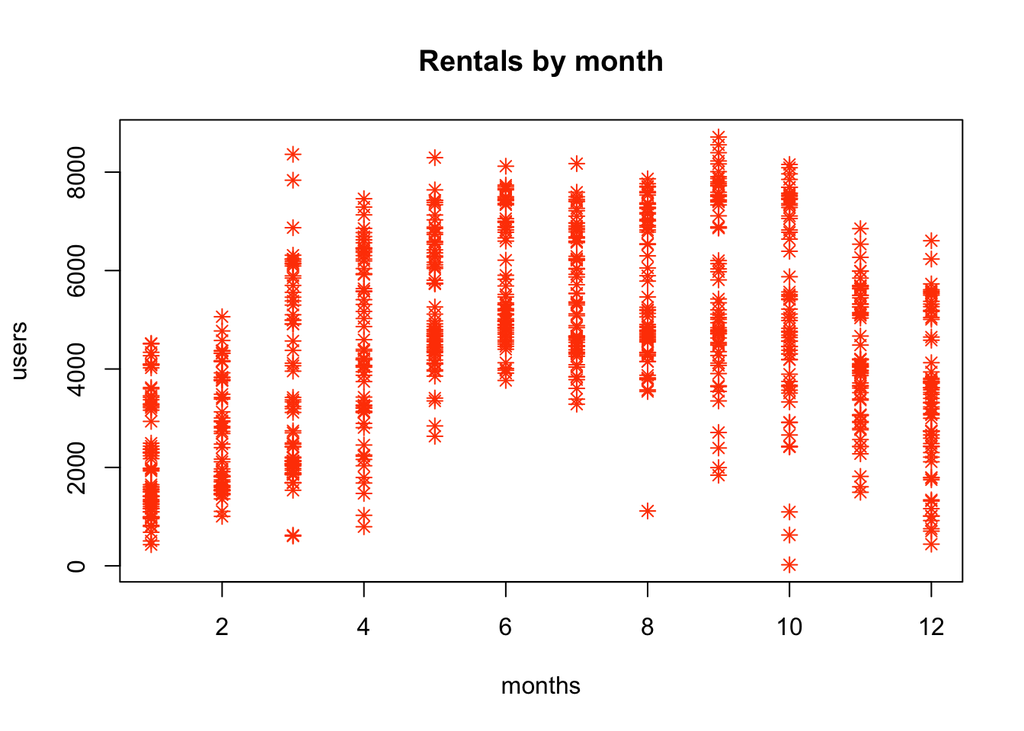

```r
plot(dat$cnt~dat$mnth, pch=8, ylab="users", xlab="months",col="orangered",main="Rentals by month")
```

This is a plot of how many bikes were being rented during each month. Please note that for this plot we used the day data set and not the hour data set.

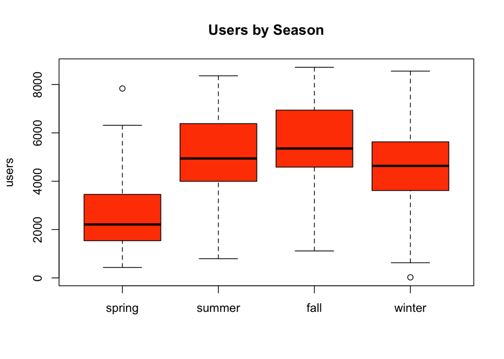

```r
boxplot(dat$cnt~dat$season,names=c("spring","summer","fall","winter"),ylab="users",col="orangered",main="Users by Season")
```

This is a boxplot of bikes that were being rented based on the season. We expected the most bikes to be rented during the summer but realized that the most bikes being rented was in the fall.

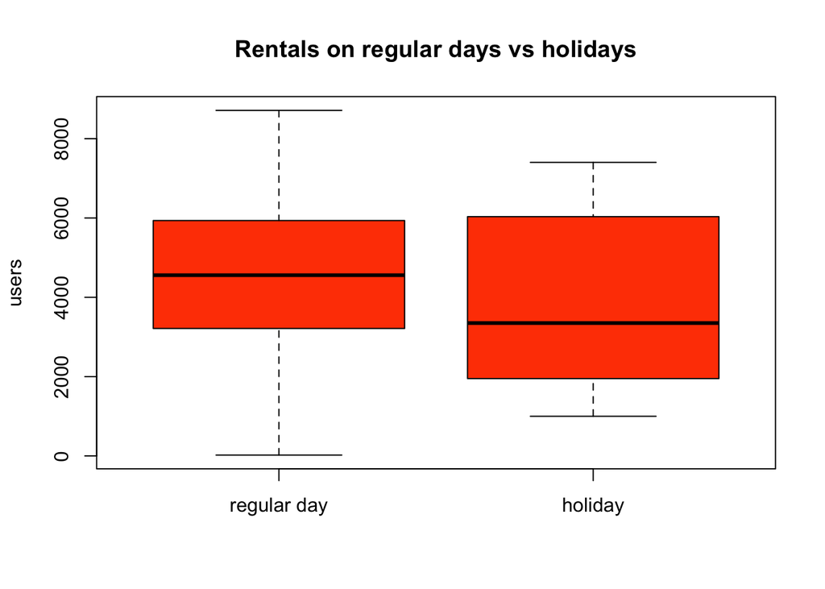

```r
boxplot(dat$cnt~dat$holiday, names=c("regular day","holiday"), ylab="users",col="orangered",main="Rentals on regular days vs holidays")
```

This is a boxplot of bikes that were rented on holidays and bikes that were rented on regular days.

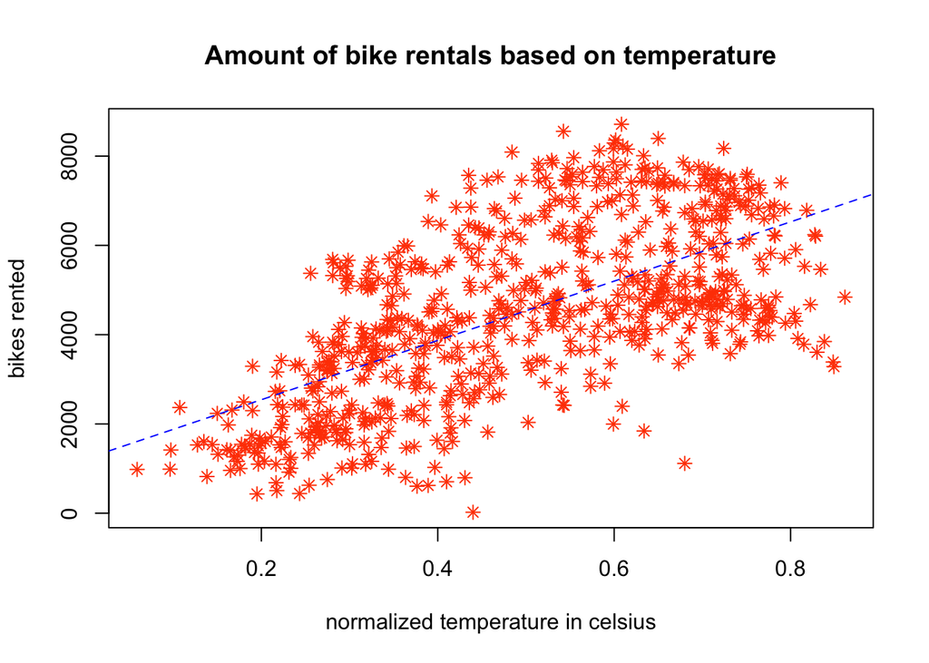

```r
plot(cnt ~ temp,data=dat,col="orangered",main="Amount of bike rentals based on temperature",ylab="bikes rented",xlab="normalized temperature in celsius",pch=8)
biketemp <- lm(cnt~temp,data=dat)
abline(biketemp,col="blue",lty="dashed")
```

This tells us that the hotter the weather, the more bike rentals there was.

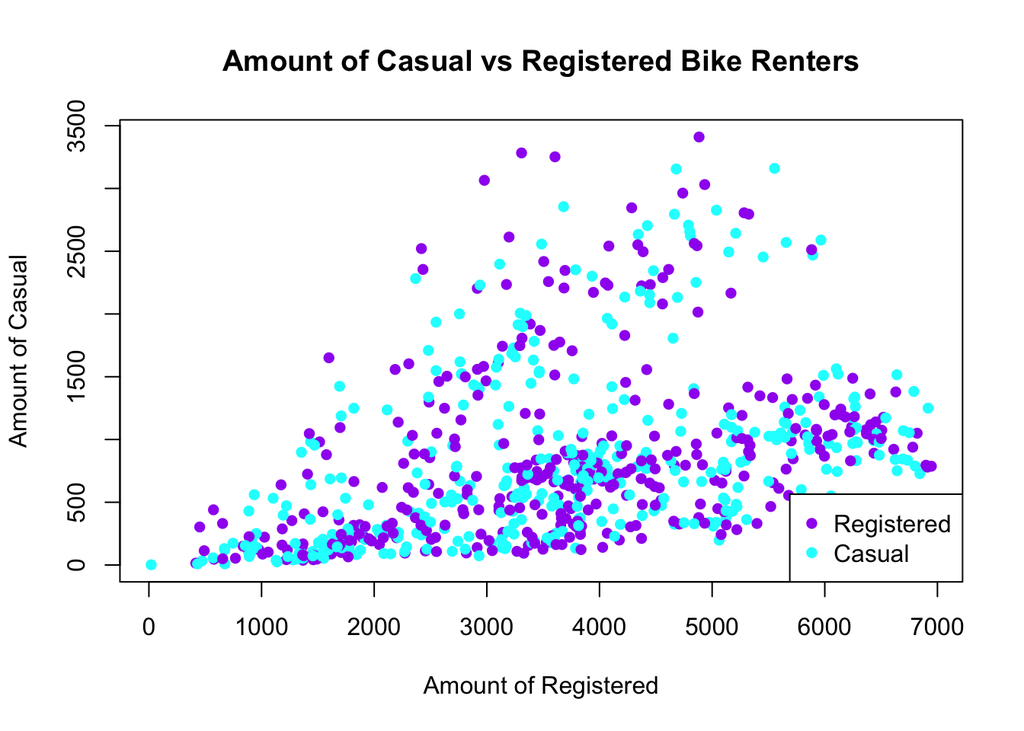

```r
plot(x=dat$registered,y=dat$casual,xlab = "Amount of Registered",ylab = "Amount of Casual",col=c("purple","cyan"),pch=16,main = "Amount of Casual vs Registered Bike Renters")
legend("bottomright", 95, legend=c("Registered", "Casual"),col=c("purple", "cyan"),pch = 16)
```

This is a scatterplot showing the amount of casual bike renters compared to registered bike renters. There is almost twice as many registered bike renters than their is casual. This gives us an idea of how many renters are actually one time users or not.

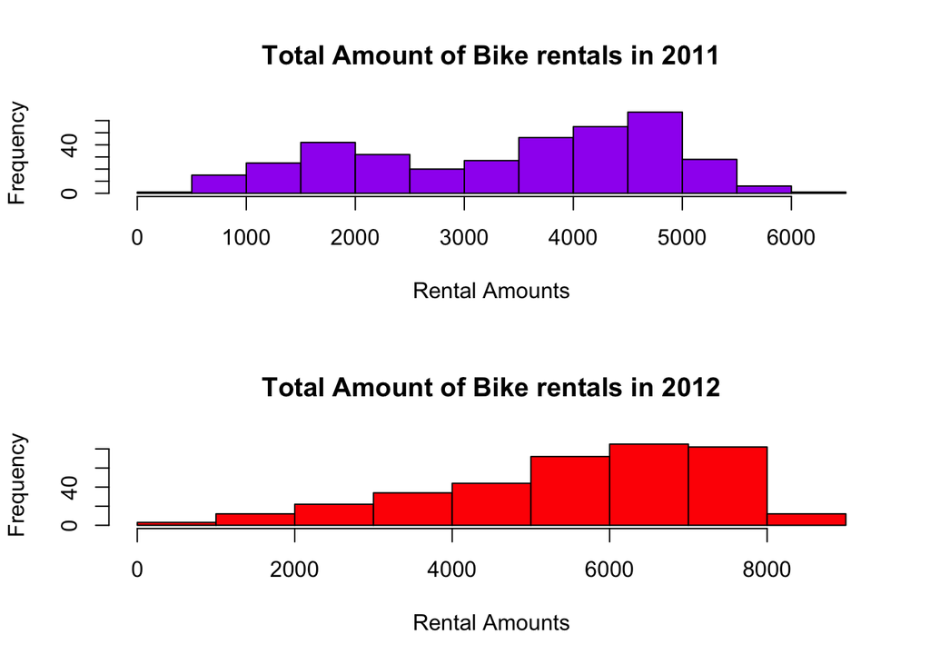

```r
par(mfrow=c(2,1))
Year2011 = dat[dat$yr==0,]
hist(Year2011$cnt,col = "purple",main = "Total Amount of Bike rentals in 2011",xlab = "Rental Amounts")
Year2012 = dat[dat$yr==1,]
hist(Year2012$cnt,col = "red",main = "Total Amount of Bike rentals in 2012",xlab = "Rental Amounts")
```

We wanted to get an idea of how bike rentals compared between years 2011 and 2012. 2012 was much better in all aspects as seen by the plot above. We have also removed the index number of each record ,registered and casual bikes from the dataset.

```r
source("https://raw.githubusercontent.com/grbruns/cst383/master/lin-regr-util.R")
source("https://raw.githubusercontent.com/grbruns/cst383/master/class-util.R")
set.seed(123)
library(rpart)
library(e1071)
library(rpart.plot)
library(caret)
library(corrplot)
library(cluster)
library(fpc)
dsets = split_data(dat, c(3,1))
tr_dat = dsets[[1]]
te_dat = dsets[[2]]
```

## Decision Trees Regression Model

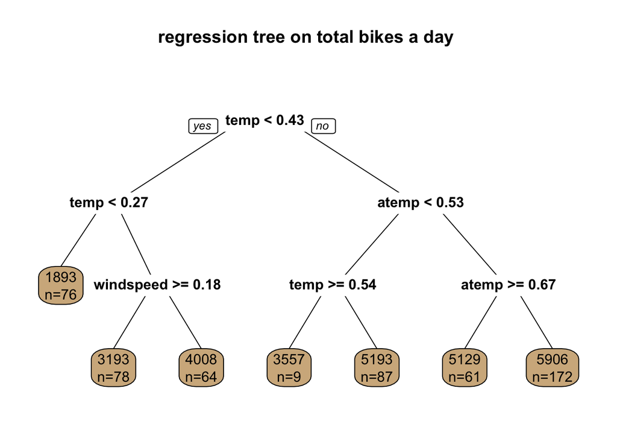

```r
dat = dat[,-1]
dat = dat[,-14]
dat = dat[,-13]
dat = dat[,-1]

model2 = rpart(cnt~ holiday +temp + atemp + workingday + windspeed, data = tr_dat)
prp(model2, extra= 1, varlen=-10,
main="regression tree on total bikes a day ",
box.col="tan")
```

```r
predicted = predict(model2, te_dat)
actual =  te_dat$cnt
errors = te_dat$cnt - predicted
rmse = sqrt(mean(errors^2))
rmse
```

```
## [1] 1559.96
```

We calculated the rmse of the Regression Tree model.

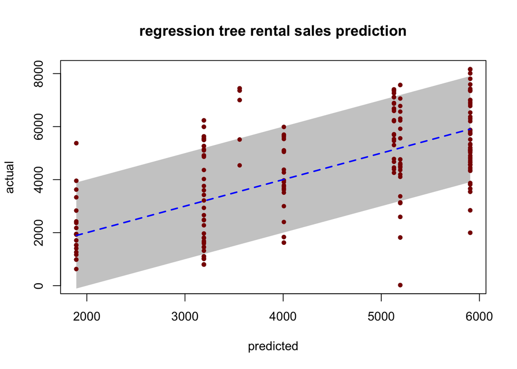

```r
plot_predict_actual(predicted, actual, 2000,
"regression tree rental sales prediction")
```

We actually found out that decision tree regression model didn’t perform very well on this particular dataset by plotting predicted values vs actual values.

## Linear Regression Model

```r
oldfit=lm(cnt~.,data = dat)
varImp(oldfit)
```

```
##              Overall
## season      9.309748
## yr         31.306209
## mnth        2.282301
## holiday     2.581531
## weekday     4.237213
## workingday  1.671455
## weathersit  7.796851
## temp        1.445436
## atemp       2.248207
## hum         3.244832
## windspeed   5.605293
```

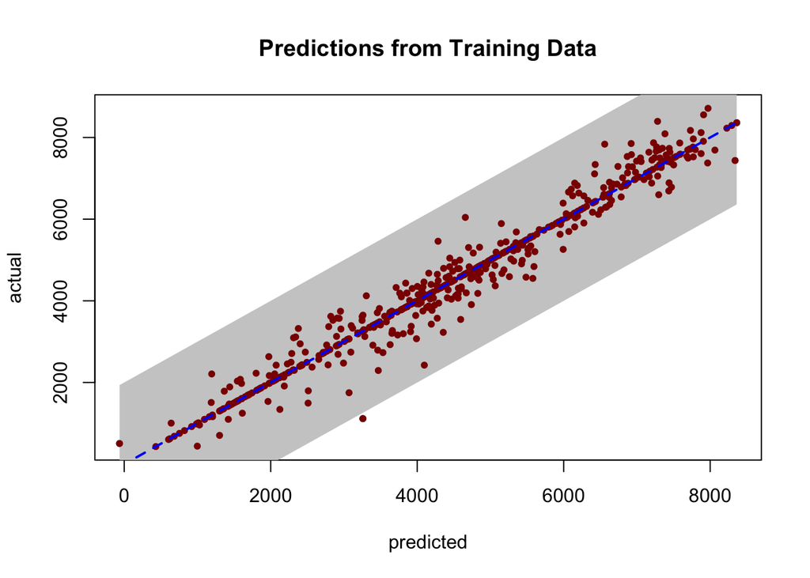

```r
fit = lm(cnt~season+mnth+holiday+weekday+weathersit+windspeed+hum+atemp+as.factor(temp)+
           as.factor(yr),data = dat)
predicted = predict(fit, tr_dat)
actual= tr_dat$cnt
plot_predict_actual(predicted,actual,2000,title = "Predictions from Training Data")
```

This model is fitted using the best features to predict rentals of bikes in a day for the next year. This shows us that the model did pretty well on the training data, but that’s expected, the real test is running it on test data.

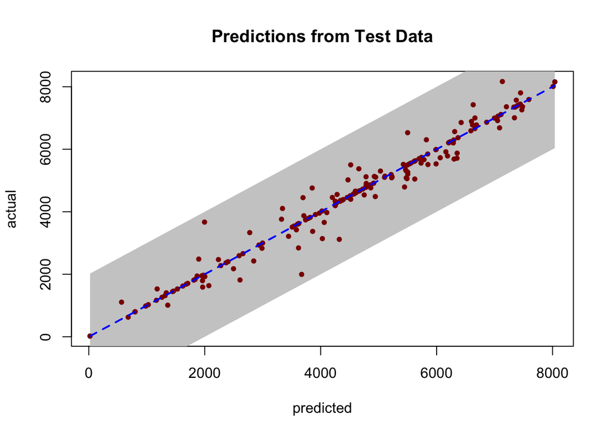

```r
predicted3 = predict(fit, te_dat)
actual3= te_dat$cnt
plot_predict_actual(predicted3,actual3,2000,title = "Predictions from Test Data")
```

Here we ran our fitted model on our test data and as you can see, it did a decent job of predicting bike rentals in a day. There is alot of residual on some parts but for the most part, the dots are close to the fitted line.

```r
predicted = predict(fit, te_dat)
errors = te_dat$cnt - predicted
rmse = sqrt(mean(errors^2))
paste0("The RMSE is ",rmse)
```

```
## [1] "The RMSE is 355.482076608152"
```